# Projekt iz kolegija Statistička analiza podataka

KGB (Ivo Karamatić, Vjeran Grozdanić, Jelena Bratulić)

20. svibnja 2020.

## *Učitavanje i transformacija podataka*

Podaci se nalaze u zasebnim csv datotekama. Dodatno ćemo u analizama koristiti i izvedene varijable iz prethodno spomenutih podataka pa je potrebno izračunati vrijednosti rasta varijabli. Godišnji rast BDP-a mjerimo prema sljedećoj formuli: $rastBDP = \frac{BDP_{N} - BDP_{N-1}}{BDP_{N-1}}$. Varijabla $BDP_{N}$ predstavlja vrijednost BDP-a u tekućoj godini, a varijabla $BDP_{N-1}$ predstavlja vrijednost BDP-a u prethodnoj godini. Dijeljenje s vrijednošću iz prethodne godine nužno je zbog inflacije. Kada bismo riječima trebali objasniti značenje ove varijable, okvirna definicija mogla bi glasiti: Godišnji rast BDP-a je razlika između BDP-a u tekućoj godini i BDP-a u prethodnoj godini prilagođena monetarnoj situaciji iz prethodne godine. Analogno vrijedi i za rast izvoza, uvoza te BDP-a po glavi stanovnika.

```r
rm(list=ls()) # cisti sve lokalne varijable

export.data <- read_csv("../data/Export_data.csv")
import.data <- read_csv("../data/Import_data.csv")
gdp.data <- read_csv("../data/GDP_data.csv")
gdp.per.capita.data <- read_csv("../data/GDPpercapita_data.csv")
# sve drzave u podacima vec imaju iste godine, 1979 - 2018

export.data %>% filter(LOCATION=="AUS" | LOCATION=="NOR" | LOCATION=="USA" | LOCATION=="KOR") %>% select(LOCATION, TIME, Value) %>% rename(EXPORT = Value) -> export.data.filter
import.data %>% filter(LOCATION=="AUS" | LOCATION=="NOR" | LOCATION=="USA" | LOCATION=="KOR") %>% select(LOCATION, TIME, Value) %>% rename(IMPORT = Value)-> import.data.filter
gdp.data %>% filter(LOCATION=="AUS" | LOCATION=="NOR" | LOCATION=="USA" | LOCATION=="KOR") %>% select(LOCATION, TIME, Value) %>% rename(GDP = Value) -> gdp.data.filter
gdp.per.capita.data %>% filter(LOCATION=="AUS" | LOCATION=="NOR" | LOCATION=="USA" | LOCATION=="KOR") %>% select(LOCATION, TIME, Value) %>% rename(GDP_PER_CAPITA = Value) -> gdp.per.capita.data.filter

# spajanje svih podataka u jednu tablicu

sap.data <- inner_join(export.data.filter, import.data.filter, by = c("LOCATION" = "LOCATION", "TIME" = "TIME"))
sap.data <- inner_join(sap.data, gdp.data.filter, by = c("LOCATION" = "LOCATION", "TIME" = "TIME"))
sap.data <- inner_join(sap.data, gdp.per.capita.data.filter, by = c("LOCATION" = "LOCATION", "TIME" = "TIME"))

rm(list=setdiff(ls(), "sap.data")) # cisti sve varijable osim sap.data koja ce biti koristena za daljnju obradu podataka

# izracun rasta

sap.data <- mutate(sap.data, EXPORT_GROWTH = ifelse(LOCATION == lag(LOCATION), (EXPORT - lag(EXPORT)) / lag(EXPORT), NA))
sap.data <- mutate(sap.data, IMPORT_GROWTH = ifelse(LOCATION == lag(LOCATION), (IMPORT - lag(IMPORT)) / lag(IMPORT), NA))
sap.data <- mutate(sap.data, GDP_GROWTH = ifelse(LOCATION == lag(LOCATION), (GDP - lag(GDP)) / lag(GDP), NA))
sap.data <- mutate(sap.data, GDP_PER_CAPITA_GROWTH = ifelse(LOCATION == lag(LOCATION), (GDP_PER_CAPITA - lag(GDP_PER_CAPITA)) / lag(GDP_PER_CAPITA), NA))

# izracun prosjeka i standardne devijacije

sap.data.summary <- sap.data %>% group_by(LOCATION) %>% summarise(EXPORT_MEAN=mean(EXPORT, na.rm=T), EXPORT_SD=sd(EXPORT, na.rm=T), EXPORT_GROWTH_MEAN=mean(EXPORT_GROWTH, na.rm=T), EXPORT_GROWTH_SD=sd(EXPORT_GROWTH, na.rm=T), IMPORT_MEAN=mean(IMPORT, na.rm=T), IMPORT_SD=sd(IMPORT, na.rm=T), IMPORT_GROWTH_MEAN=mean(IMPORT_GROWTH, na.rm=T), IMPORT_GROWTH_SD=sd(IMPORT_GROWTH, na.rm=T), GDP_MEAN=mean(GDP, na.rm=T), GDP_SD=sd(GDP, na.rm=T), GDP_GROWTH_MEAN=mean(GDP_GROWTH, na.rm=T), GDP_GROWTH_SD=sd(GDP_GROWTH, na.rm=T), GDP_PER_CAPITA_MEAN=mean(GDP_PER_CAPITA, na.rm=T), GDP_PER_CAPITA_SD=sd(GDP_PER_CAPITA, na.rm=T), GDP_PER_CAPITA_GROWTH_MEAN=mean(GDP_PER_CAPITA_GROWTH, na.rm=T), GDP_PER_CAPITA_GROWTH_SD=sd(GDP_PER_CAPITA_GROWTH, na.rm=T))

# izracun dodatnih varijabli za testiranja

aus_test_data = sap.data %>% filter(LOCATION=="AUS")
kor_test_data = sap.data %>% filter(LOCATION=="KOR")
nor_test_data = sap.data %>% filter(LOCATION=="NOR")
usa_test_data = sap.data %>% filter(LOCATION=="USA")

e = rep("E", 39)
i = rep("I", 39)
f = rep("F", 39)
s = rep("S", 39)

aus_ei_test = data.frame(na.omit(aus_test_data$EXPORT_GROWTH), e)
ii = data.frame(na.omit(aus_test_data$IMPORT_GROWTH), i)
names(ii) = names(aus_ei_test)
aus_ei_test = rbind(aus_ei_test, ii)

kor_ei_test = data.frame(na.omit(kor_test_data$EXPORT_GROWTH), e)
ii = data.frame(na.omit(kor_test_data$IMPORT_GROWTH), i)
names(ii) = names(kor_ei_test)
kor_ei_test = rbind(kor_ei_test, ii)

nor_ei_test = data.frame(na.omit(nor_test_data$EXPORT_GROWTH), e)
ii = data.frame(na.omit(nor_test_data$IMPORT_GROWTH), i)
names(ii) = names(nor_ei_test)
nor_ei_test = rbind(nor_ei_test, ii)

usa_ei_test = data.frame(na.omit(usa_test_data$EXPORT_GROWTH), e)
ii = data.frame(na.omit(usa_test_data$IMPORT_GROWTH), i)
names(ii) = names(usa_ei_test)
usa_ei_test = rbind(usa_ei_test, ii)

aus_gdp_test = data.frame(na.omit(aus_test_data$GDP_GROWTH), e)
ii = data.frame(na.omit(aus_test_data$GDP_PER_CAPITA_GROWTH), i)
names(ii) = names(aus_gdp_test)
aus_gdp_test = rbind(aus_gdp_test, ii)

kor_gdp_test = data.frame(na.omit(kor_test_data$GDP_GROWTH), e)
ii = data.frame(na.omit(kor_test_data$GDP_PER_CAPITA_GROWTH), i)
names(ii) = names(kor_gdp_test)
kor_gdp_test = rbind(kor_gdp_test, ii)

nor_gdp_test = data.frame(na.omit(nor_test_data$GDP_GROWTH), e)
ii = data.frame(na.omit(nor_test_data$GDP_PER_CAPITA_GROWTH), i)
names(ii) = names(nor_gdp_test)
nor_gdp_test = rbind(nor_gdp_test, ii)

usa_gdp_test = data.frame(na.omit(usa_test_data$GDP_GROWTH), e)
ii = data.frame(na.omit(usa_test_data$GDP_PER_CAPITA_GROWTH), i)
names(ii) = names(usa_gdp_test)
usa_gdp_test = rbind(usa_gdp_test, ii)

kor_nor_test = data.frame(na.omit(kor_test_data$GDP_GROWTH), f)
ii = data.frame(na.omit(nor_test_data$GDP_GROWTH), s)
names(ii) = names(kor_nor_test)
kor_nor_test = rbind(kor_nor_test, ii)

kor_usa_test = data.frame(na.omit(kor_test_data$GDP_GROWTH), f)
ii = data.frame(na.omit(usa_test_data$GDP_GROWTH), s)
names(ii) = names(kor_usa_test)
kor_usa_test = rbind(kor_usa_test, ii)

nor_usa_test = data.frame(na.omit(nor_test_data$GDP_GROWTH), f)
ii = data.frame(na.omit(usa_test_data$GDP_GROWTH), s)
names(ii) = names(nor_usa_test)
nor_usa_test = rbind(nor_usa_test, ii)

gdp_g_all_states = data.frame(na.omit(aus_test_data$GDP_GROWTH), e)
ii = data.frame(na.omit(kor_test_data$GDP_GROWTH), i)
names(ii) = names(gdp_g_all_states)
gdp_g_all_states = rbind(gdp_g_all_states, ii)
ii = data.frame(na.omit(nor_test_data$GDP_GROWTH), f)
names(ii) = names(gdp_g_all_states)
gdp_g_all_states = rbind(gdp_g_all_states, ii)
ii = data.frame(na.omit(usa_test_data$GDP_GROWTH), s)
names(ii) = names(gdp_g_all_states)
gdp_g_all_states = rbind(gdp_g_all_states, ii)


colnames(aus_ei_test) = c("NUMBERS", "MARKER")
colnames(kor_ei_test) = c("NUMBERS", "MARKER")
colnames(nor_ei_test) = c("NUMBERS", "MARKER")
colnames(usa_ei_test) = c("NUMBERS", "MARKER")
colnames(kor_nor_test) = c("NUMBERS", "MARKER")
colnames(kor_usa_test) = c("NUMBERS", "MARKER")
colnames(nor_usa_test) = c("NUMBERS", "MARKER")
colnames(gdp_g_all_states) = c("NUMBERS", "MARKER")

e = rep("E", 40)
i = rep("I", 40)
f = rep("F", 40)
s = rep("S", 40)

aus2_ei_test = data.frame(na.omit(aus_test_data$EXPORT), e)
ii = data.frame(na.omit(aus_test_data$IMPORT), i)
names(ii) = names(aus2_ei_test)
aus2_ei_test = rbind(aus2_ei_test, ii)

kor2_ei_test = data.frame(na.omit(kor_test_data$EXPORT), e)
ii = data.frame(na.omit(kor_test_data$IMPORT), i)
names(ii) = names(kor2_ei_test)
kor2_ei_test = rbind(kor2_ei_test, ii)

nor2_ei_test = data.frame(na.omit(nor_test_data$EXPORT), e)
ii = data.frame(na.omit(nor_test_data$IMPORT), i)
names(ii) = names(nor2_ei_test)
nor2_ei_test = rbind(nor2_ei_test, ii)

usa2_ei_test = data.frame(na.omit(usa_test_data$EXPORT), e)
ii = data.frame(na.omit(usa_test_data$IMPORT), i)
names(ii) = names(usa2_ei_test)
usa2_ei_test = rbind(usa2_ei_test, ii)

colnames(aus2_ei_test) = c("NUMBERS", "MARKER")
colnames(kor2_ei_test) = c("NUMBERS", "MARKER")
colnames(nor2_ei_test) = c("NUMBERS", "MARKER")
colnames(usa2_ei_test) = c("NUMBERS", "MARKER")

colnames(aus_gdp_test) = c("NUMBERS", "MARKER")
colnames(kor_gdp_test) = c("NUMBERS", "MARKER")
colnames(nor_gdp_test) = c("NUMBERS", "MARKER")
colnames(usa_gdp_test) = c("NUMBERS", "MARKER")
```

## *Pogled s ekonomskog aspekta*

U ekonomiji, snaga gospodarstva neke države mjeri se uglavnom BDP-om (Bruto domaćim proizvodom). To je ekonomski faktor koji se najčešće računa prema sljedećoj formuli: $Y = C + I + G + X$. U upravo navedenoj formuli Y označava BDP, C označava osobnu potrošnju, I označava investicije, G označava državnu potrošnju, a X označava neto izvoz. Neto izvoz je definiran sljedećom formulom: $X = ukupanIzvoz - ukupanUvoz$. Dakle, možemo zaključiti da matematička veza između uvoza neke države, izvoza neke države i njenog gospodarstva svakako postoji.

S obzirom da na BDP, osim uvoza i izvoza, utječu i potrošačke navike društva, logično je za očekivati da će ukupni BDP kod država s većim brojem stanovnika biti uglavnom veći te da bismo, kako bismo imali dobru predodžbu gospodarske snage neke države u odnosu na njeno stanovništvo, trebali uspoređivati BDP po glavi stanovnika. Pogledajmo malu usporedbu između SAD-a, Južne Koreje, Norveške i Australije. Na prvom grafu imamo vrijednosti BDP-a u periodu od 1979. do 2018. godine. Gledajući samo taj graf, moglo bi se zaključiti da je osoba u SAD-u nemjerljivo bogatija i ekonomski prosperitetnija u odnosu na ljude u preostalim zemljama. Međutim, pogledamo li drugi graf koji prikazuje BDP po glavi stanovnika u istom vremenskom periodu, vidimo da su ekonomije ostalih zemalja ne samo usporedive, već u nekoliko navrata i bolje od ekonomije SAD-a.

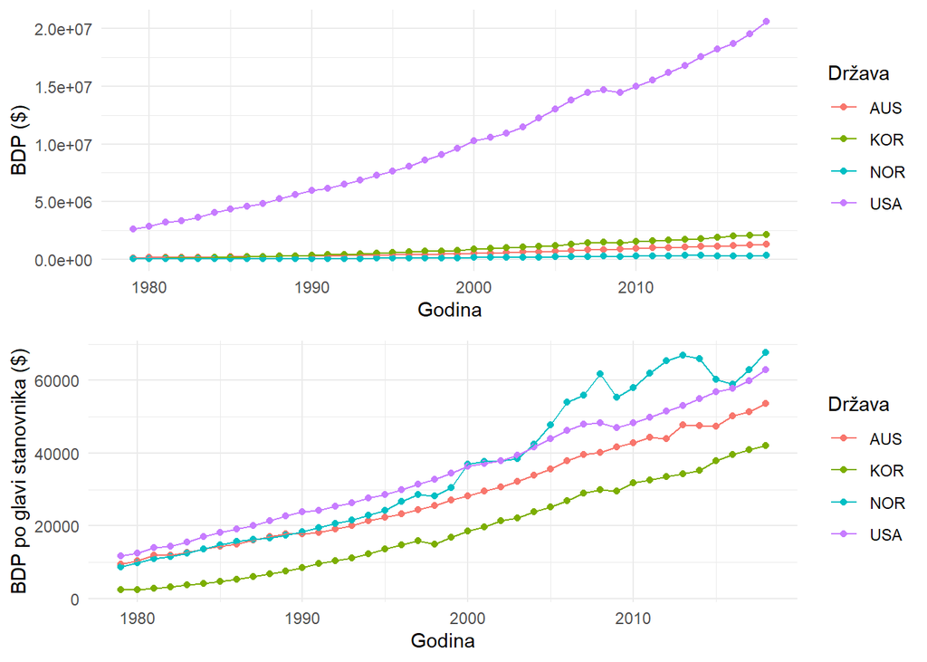

```r
p1 = ggplot(sap.data, aes(TIME, colour = LOCATION)) + geom_point(aes(y = GDP)) + geom_line(aes(y = GDP)) + labs(x = "Godina", y = "BDP ($)", colour = "Država") + theme_minimal()

p2 = ggplot(sap.data, aes(TIME, colour = LOCATION)) + geom_point(aes(y = GDP_PER_CAPITA)) + geom_line(aes(y = GDP_PER_CAPITA)) + labs(x = "Godina", y = "BDP po glavi stanovnika ($)", colour = "Država") + theme_minimal()
plot_grid(p1, p2, ncol= 1)
```

Nadalje, možemo vizualizirati i kretanje gospodarskog rasta kroz navedne godine. Definiciju gospodarskog rasta dali smo u prethodnom odijelku, no spomenimo samo kako je gospodarski rast jedan od najvažnih pokazatelja stabilnosti i jačine gospodarstva neke države. Na sljedećem grafu pogledajmo kako se rast BDP-a u naše 4 države kretao kroz vrijeme.

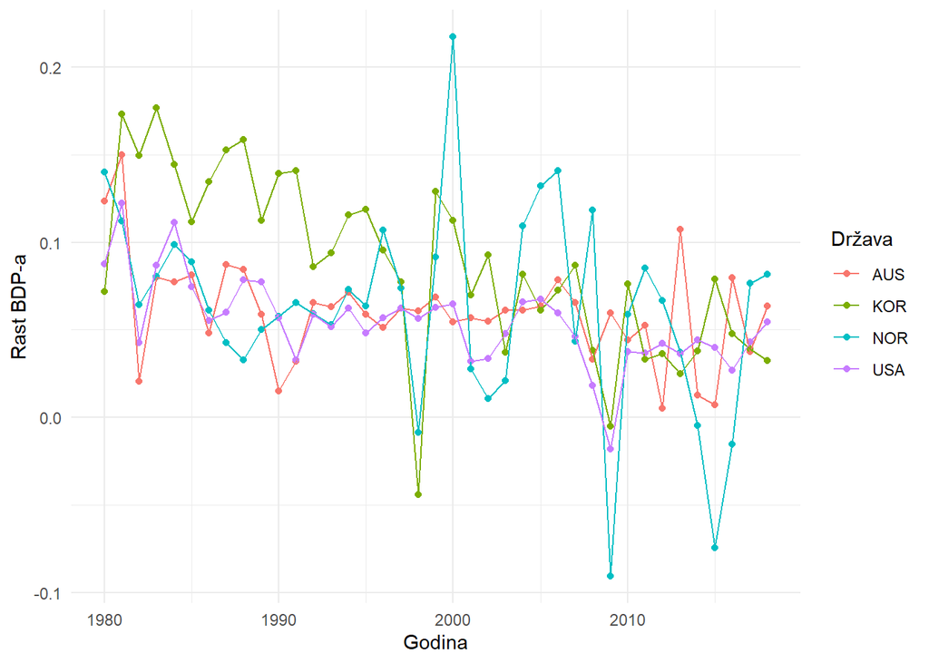

```r
ggplot(na.omit(sap.data), aes(TIME, colour = LOCATION)) + geom_point(aes(y = GDP_GROWTH)) + geom_line(aes(y = GDP_GROWTH)) + labs(x = "Godina", y = "Rast BDP-a", colour = "Država") + theme_minimal()
```

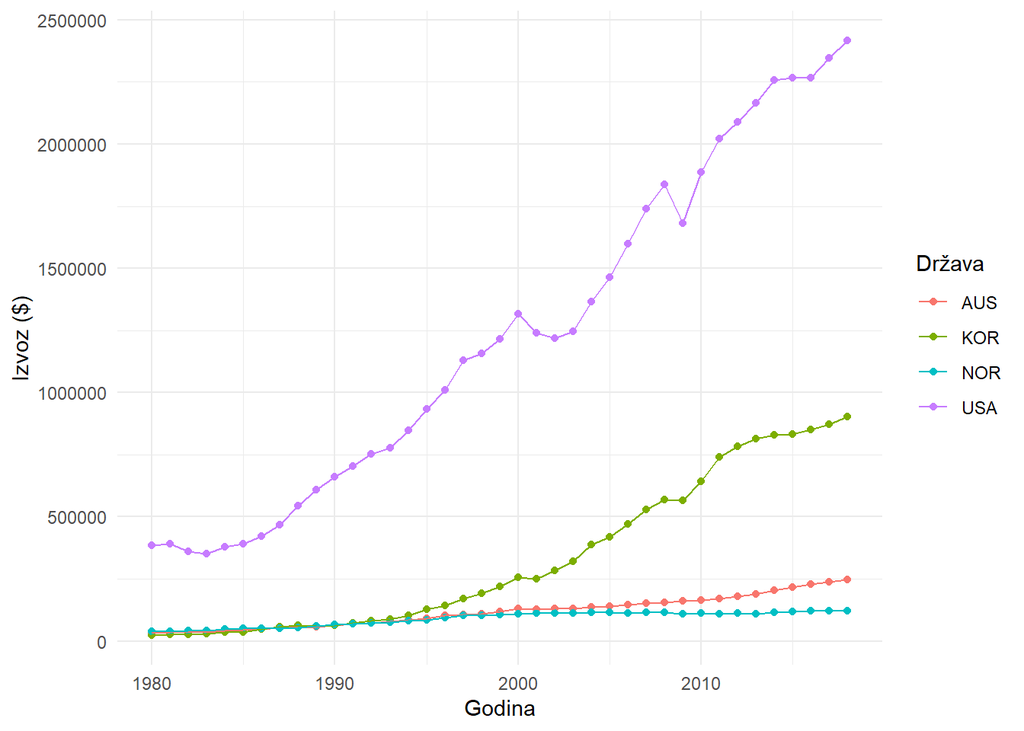

```r
ggplot(na.omit(sap.data), aes(TIME, colour = LOCATION)) + geom_point(aes(y = EXPORT)) + geom_line(aes(y = EXPORT)) + labs(x = "Godina", y = "Izvoz ($)", colour = "Država") + theme_minimal()
```

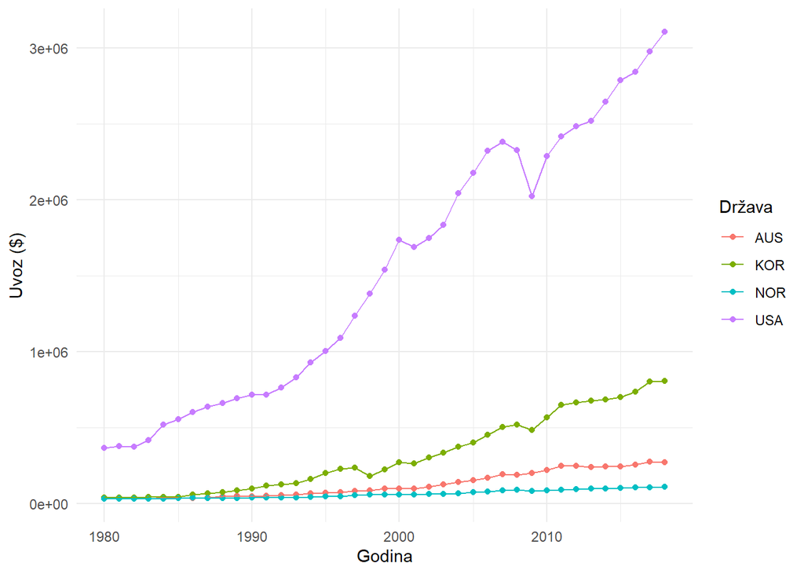

```r
ggplot(na.omit(sap.data), aes(TIME, colour = LOCATION)) + geom_point(aes(y =IMPORT)) + geom_line(aes(y = IMPORT)) + labs(x = "Godina", y = "Uvoz ($)", colour = "Država") + theme_minimal()
```

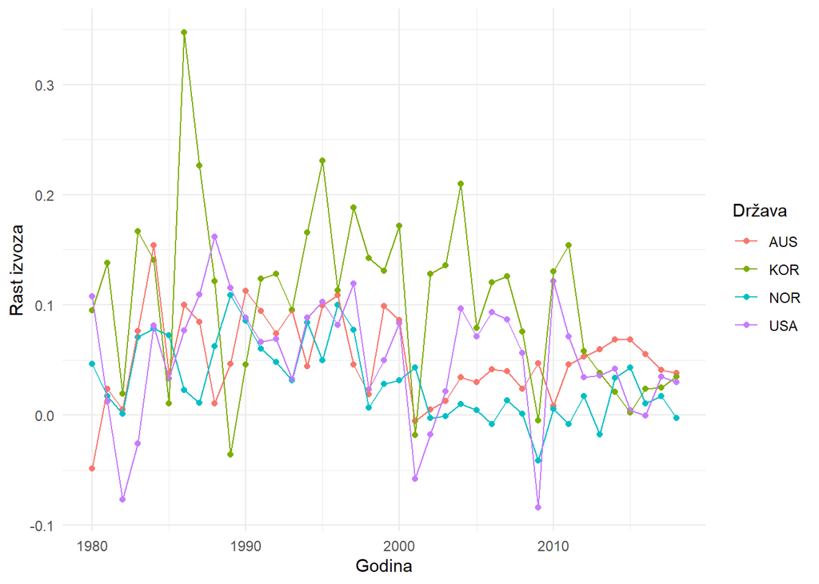

```r
ggplot(na.omit(sap.data), aes(TIME, colour = LOCATION)) + geom_point(aes(y = EXPORT_GROWTH)) + geom_line(aes(y = EXPORT_GROWTH)) + labs(x = "Godina", y = "Rast izvoza", colour = "Država") + theme_minimal()
```

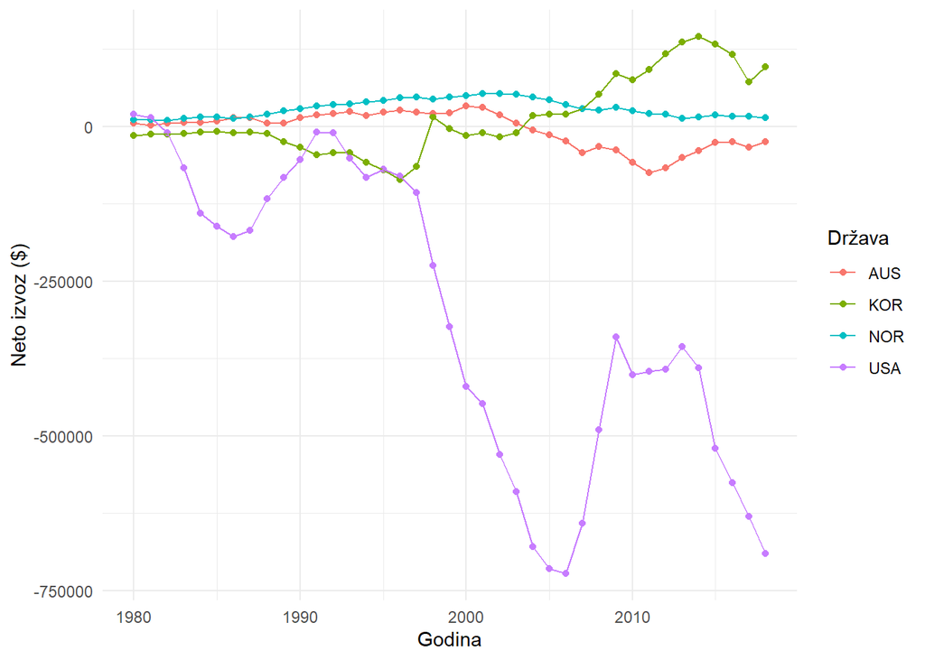

```r
ggplot(na.omit(sap.data), aes(TIME, colour = LOCATION)) + geom_point(aes(y = EXPORT - IMPORT)) + geom_line(aes(y = EXPORT - IMPORT)) + labs(x = "Godina", y = "Neto izvoz ($)", colour = "Država") + theme_minimal()
```

## *Stršeće vrijednosti*

Kao što smo već spomenuli, rast BDP-a, izvoza i uvoza dobri su pokazatelji stabilnosti države i jačine njezinog gospodarstva. To je vidljivo i analiziranjem stršećih vrijednosti pomoću Box-plot grafa. Neka vrijednost je stršeća ukoliko se od središnje vrijednosti razlikuje za više od 3 $\sigma$.

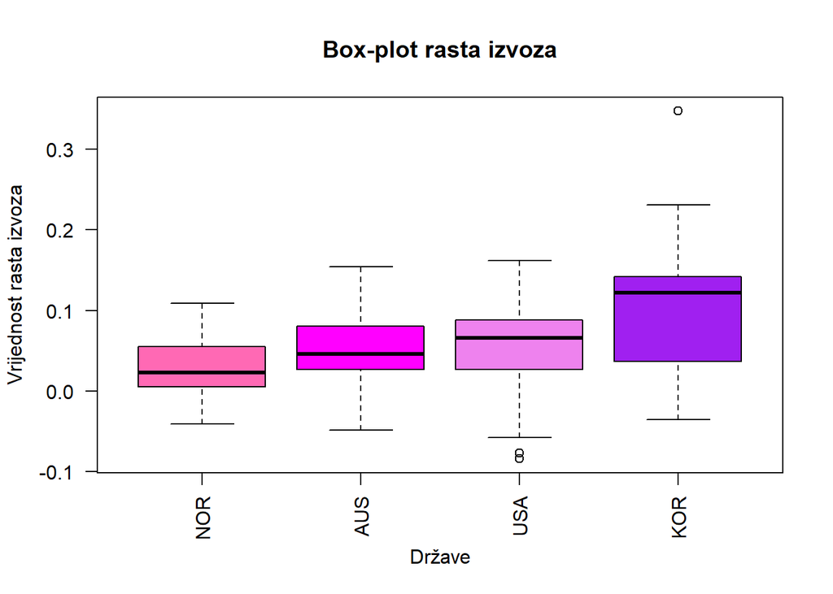

```r
boxplot(nor_test_data$EXPORT_GROWTH, aus_test_data$EXPORT_GROWTH, usa_test_data$EXPORT_GROWTH, kor_test_data$EXPORT_GROWTH,
main = "Box-plot rasta izvoza",
at = c(1,2,3,4),
names = c("NOR", "AUS", "USA", "KOR"),
las = 2,
col = c("hot pink","magenta", "violet", "purple"),
border = "black",
xlab = "Države",
ylab = 'Vrijednost rasta izvoza')
```

U ovom slučaju, strešeće vrijednosti nam ukazuju na nepravilnosti u gospodarstvu neke države. Kod Južne Koreje i SAD-a su vidljive stršeće vrijednosti koje se mogu objasniti sljedećim događajima. Južna Koreja je 1986. godine započela trgovati sa SAD-om što je u državi povećalo izvoz, a samim time možemo reći da se dogodio i veći pritok novaca nego prije. Nadalje, SAD je imala dva pada, odnosno 1982. godine te 2009.godine kada je cijeli svijet zahvatila ekonomska kriza, što se i vidljivo osjetilo u gospodarstvu SAD-a.

## *Grafičke provjere podataka*

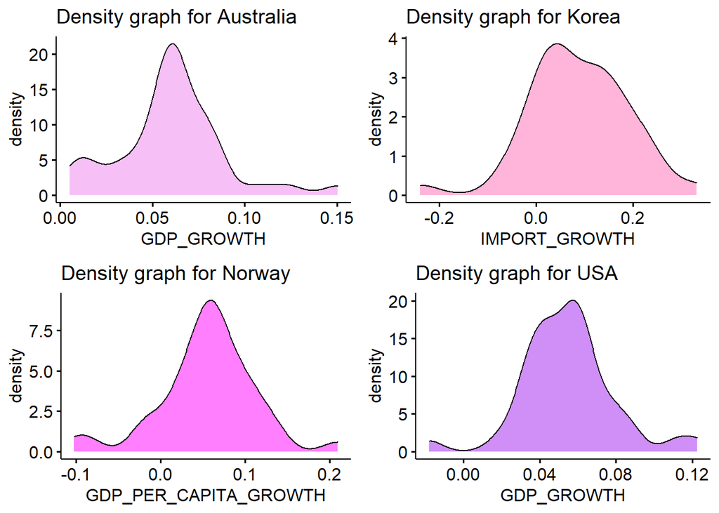

```r
p1 =ggdensity(na.omit(aus_test_data$GDP_GROWTH), main = "Density graph for Australia", xlab = "GDP_GROWTH", fill = 'violet')
p2 = ggdensity(na.omit(kor_test_data$IMPORT_GROWTH), main = "Density graph for Korea", xlab = "IMPORT_GROWTH", fill = 'hot pink')
p3 = ggdensity(na.omit(nor_test_data$GDP_PER_CAPITA_GROWTH), main = "Density graph for Norway", xlab = "GDP_PER_CAPITA_GROWTH", fill = 'magenta')
p4 = ggdensity(na.omit(usa_test_data$GDP_GROWTH), main = "Density graph for USA", xlab = "GDP_GROWTH", fill = 'purple')
plot_grid(p1, p2, p3, p4)
```

Iz samih grafičkih prikaza distribucije populacije ne možemo s velikom sigurnošću odrediti ima li neka populacija normalnu razdiobu ili ne. Iako svi grafovi podsjećaju na normalnu distribuciju, većina njih ima dodatne teške repove koji remete distribuciju. Kako bismo s većom sigurnošću mogli odrediti distribuciju, koristit ćemo QQ grafove te dodatno i Shapiro test.

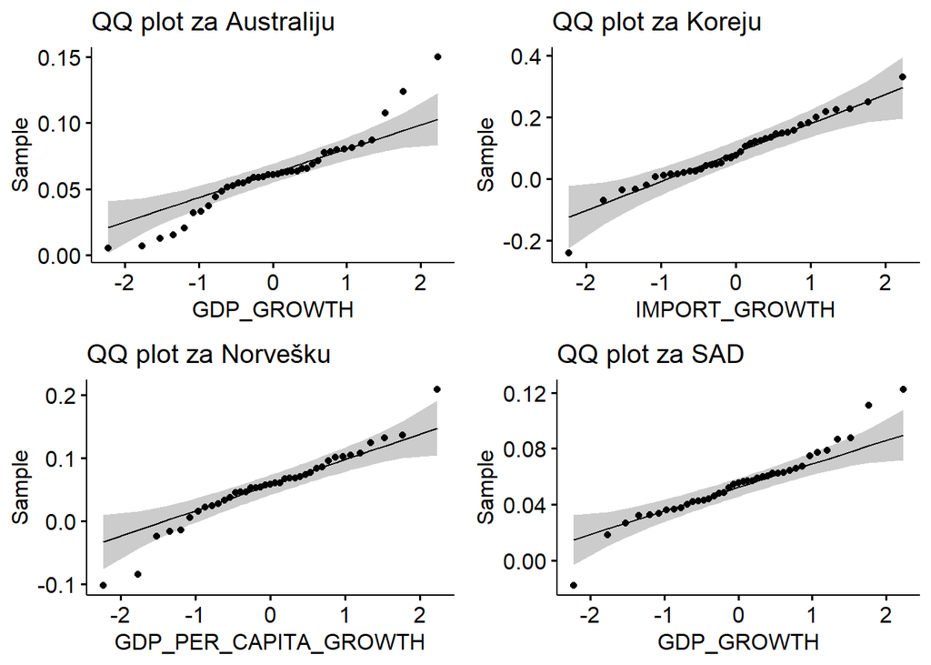

```r
p1 =ggqqplot(na.omit(aus_test_data$GDP_GROWTH), main = "QQ plot za Australiju", xlab = "GDP_GROWTH")
p2 = ggqqplot(na.omit(kor_test_data$IMPORT_GROWTH), main = "QQ plot za Koreju", xlab = "IMPORT_GROWTH")
p3 = ggqqplot(na.omit(nor_test_data$GDP_PER_CAPITA_GROWTH), main = "QQ plot za Norvešku", xlab = "GDP_PER_CAPITA_GROWTH")
p4 = ggqqplot(na.omit(usa_test_data$GDP_GROWTH), main = "QQ plot za SAD", xlab = "GDP_GROWTH")
plot_grid(p1, p2, p3, p4)
```

Shapiro testom možemo uz postavljenu razinu značajnosti od 5% biti sigurni ima li neka populacija normalnu razdiobu ili ne. Nulta hipoteza kod Shapiro testova je da uzorak ima normalnu distribuciju, dok je alternativna H1 hipoteza kako ju nema. Hipotezu H0 možemo odbaciti ukoliko je p-vrijednost testa manja od razine značajnosti, dakle manja od 5%.

```r
shapiro.test(aus_test_data$GDP_GROWTH)
```

```
##
##  Shapiro-Wilk normality test
##
## data:  aus_test_data$GDP_GROWTH
## W = 0.93703, p-value = 0.03038
```

```r
shapiro.test(kor_test_data$IMPORT_GROWTH) # --> normalna
```

```
##
##  Shapiro-Wilk normality test
##
## data:  kor_test_data$IMPORT_GROWTH
## W = 0.96901, p-value = 0.35
```

```r
shapiro.test(nor_test_data$GDP_PER_CAPITA_GROWTH) # --> normalna
```

```
##
##  Shapiro-Wilk normality test
##
## data:  nor_test_data$GDP_PER_CAPITA_GROWTH
## W = 0.95423, p-value = 0.1142
```

```r
shapiro.test(usa_test_data$GDP_GROWTH) # --> normalna
```

```
##
##  Shapiro-Wilk normality test
##
## data:  usa_test_data$GDP_GROWTH
## W = 0.94814, p-value = 0.07113
```

Provedeni testovi te grafički prikazi pokazuju nam da nemaju svi uzorci normalnu distribuciju. Zbog toga ćemo za testiranje pojedinih hipoteza morati koristiti alternativne neparametarske testove. Osim prikazanih Shapiro testova, odbacivanje nulte hipoteze dobiveno je još i za rast BDP-a per capita u Australiji te SAD-u.